# Linear Regression Example

In this example, we are playing with a diabetes dataset. Here, ten baseline variables, age, sex, body mass index, average blood pressure, and six blood serum measurements were obtained for each of n = 442 diabetes patients, as well as the response of interest, a quantitative measure of disease progression one year after baseline.

```r
# Load the diabetes dataset
diabetes <- read.csv("diabetes.csv")
head(diabetes)
```

|  | AGE | SEX | BMI | BP | S1 | S2 | S3 | S4 | S5 | S6 | Y |
| --- | --- | --- | --- | --- | --- | --- | --- | --- | --- | --- | --- |
| 1 | 59 | 2 | 32.1 | 101 | 157 | 93.2 | 38 | 4 | 4.8598 | 87 | 151 |
| 2 | 48 | 1 | 21.6 | 87 | 183 | 103.2 | 70 | 3 | 3.8918 | 69 | 75 |
| 3 | 72 | 2 | 30.5 | 93 | 156 | 93.6 | 41 | 4 | 4.6728 | 85 | 141 |
| 4 | 24 | 1 | 25.3 | 84 | 198 | 131.4 | 40 | 5 | 4.8903 | 89 | 206 |
| 5 | 50 | 1 | 23.0 | 101 | 192 | 125.4 | 52 | 4 | 4.2905 | 80 | 135 |
| 6 | 23 | 1 | 22.6 | 89 | 139 | 64.8 | 61 | 2 | 4.1897 | 68 | 97 |

### Data Preprocessing

Let’s standardize all columns that are roughly normal or uniformly distributed.

```r
library(caret)
preprocessParams1 <- preProcess(diabetes[c("AGE", "BMI", "BP", "S1", "S2", "S3", "S5", "S6", "Y")], method=c("center", "scale"))
diabetes_trans <- data.frame(predict(preprocessParams1, diabetes))
head(diabetes_trans)
```

|  | AGE | SEX | BMI | BP | S1 | S2 | S3 | S4 | S5 | S6 | Y |
| --- | --- | --- | --- | --- | --- | --- | --- | --- | --- | --- | --- |
| 1 | 0.79959404 | 2 | 1.2956203 | 0.4593201 | -0.92869347 | -0.7312360 | -0.9114178 | 4 | 0.4180572 | -0.3705686 | -0.01470281 |
| 2 | -0.03952235 | 1 | -1.0809553 | -0.5528781 | -0.17742321 | -0.4024301 | 1.5626428 | 3 | -1.4349625 | -1.9362850 | -1.00052508 |
| 3 | 1.79127703 | 2 | 0.9334755 | -0.1190789 | -0.95758848 | -0.7180838 | -0.6794746 | 4 | 0.0600875 | -0.5445371 | -0.14441627 |
| 4 | -1.87032173 | 1 | -0.2434953 | -0.7697777 | 0.25600194 | 0.5248025 | -0.7567890 | 5 | 0.4764426 | -0.1966001 | 0.69872119 |
| 5 | 0.11304427 | 1 | -0.7640785 | 0.4593201 | 0.08263188 | 0.3275189 | 0.1709838 | 4 | -0.6717404 | -0.9794583 | -0.22224434 |
| 6 | -1.94660503 | 1 | -0.8546148 | -0.4082784 | -1.44880365 | -1.6650447 | 0.8668133 | 2 | -0.8646995 | -2.0232693 | -0.71515547 |

Then apply boxcox transformations for those columns that are skewed.

```r
preprocessParams2 <- preProcess(diabetes_trans[c("S4")], method=c("BoxCox"))
diabetes_trans <- data.frame(predict(preprocessParams2, diabetes_trans))
head(diabetes_trans)
```

|  | AGE | SEX | BMI | BP | S1 | S2 | S3 | S4 | S5 | S6 | Y |
| --- | --- | --- | --- | --- | --- | --- | --- | --- | --- | --- | --- |
| 1 | 0.79959404 | 2 | 1.2956203 | 0.4593201 | -0.92869347 | -0.7312360 | -0.9114178 | 1.3862944 | 0.4180572 | -0.3705686 | -0.01470281 |
| 2 | -0.03952235 | 1 | -1.0809553 | -0.5528781 | -0.17742321 | -0.4024301 | 1.5626428 | 1.0986123 | -1.4349625 | -1.9362850 | -1.00052508 |
| 3 | 1.79127703 | 2 | 0.9334755 | -0.1190789 | -0.95758848 | -0.7180838 | -0.6794746 | 1.3862944 | 0.0600875 | -0.5445371 | -0.14441627 |
| 4 | -1.87032173 | 1 | -0.2434953 | -0.7697777 | 0.25600194 | 0.5248025 | -0.7567890 | 1.6094379 | 0.4764426 | -0.1966001 | 0.69872119 |
| 5 | 0.11304427 | 1 | -0.7640785 | 0.4593201 | 0.08263188 | 0.3275189 | 0.1709838 | 1.3862944 | -0.6717404 | -0.9794583 | -0.22224434 |
| 6 | -1.94660503 | 1 | -0.8546148 | -0.4082784 | -1.44880365 | -1.6650447 | 0.8668133 | 0.6931472 | -0.8646995 | -2.0232693 | -0.71515547 |

And transform `SEX` to dummy variables.

```r
diabetes_trans["SEX"] <- as.numeric(diabetes_trans$SEX == 1)
head(diabetes_trans)
```

|  | AGE | SEX | BMI | BP | S1 | S2 | S3 | S4 | S5 | S6 | Y |
| --- | --- | --- | --- | --- | --- | --- | --- | --- | --- | --- | --- |
| 1 | 0.79959404 | 0 | 1.2956203 | 0.4593201 | -0.92869347 | -0.7312360 | -0.9114178 | 1.3862944 | 0.4180572 | -0.3705686 | -0.01470281 |
| 2 | -0.03952235 | 1 | -1.0809553 | -0.5528781 | -0.17742321 | -0.4024301 | 1.5626428 | 1.0986123 | -1.4349625 | -1.9362850 | -1.00052508 |
| 3 | 1.79127703 | 0 | 0.9334755 | -0.1190789 | -0.95758848 | -0.7180838 | -0.6794746 | 1.3862944 | 0.0600875 | -0.5445371 | -0.14441627 |
| 4 | -1.87032173 | 1 | -0.2434953 | -0.7697777 | 0.25600194 | 0.5248025 | -0.7567890 | 1.6094379 | 0.4764426 | -0.1966001 | 0.69872119 |
| 5 | 0.11304427 | 1 | -0.7640785 | 0.4593201 | 0.08263188 | 0.3275189 | 0.1709838 | 1.3862944 | -0.6717404 | -0.9794583 | -0.22224434 |
| 6 | -1.94660503 | 1 | -0.8546148 | -0.4082784 | -1.44880365 | -1.6650447 | 0.8668133 | 0.6931472 | -0.8646995 | -2.0232693 | -0.71515547 |

### Splitting dataset for cross validation

First, we split the data into two groups: a training set and a test set. To do this, the `sample` function is used.

```r
#Preparing Data Sets
trows <- floor(0.65 * nrow(diabetes_trans))
train_idx <- sample(seq_len(nrow(diabetes_trans)), size = trows)
train <- diabetes_trans[train_idx,]
test <- diabetes_trans[-train_idx,]
```

### Data Modeling

Here we create a linear regression model between `Y`, which is our target using all features in the data.

```r
hlm <- lm(formula = Y ~ . , data = train)
summary(hlm)
```

```
Call:
lm(formula = Y ~ ., data = train)

Residuals:
     Min       1Q   Median       3Q      Max
-2.00518 -0.48762  0.01621  0.48221  1.85857

Coefficients:
            Estimate Std. Error t value Pr(>|t|)
(Intercept) -0.38021    0.64047  -0.594  0.55324
AGE         -0.03598    0.04564  -0.788  0.43117
SEX          0.38515    0.09553   4.032 7.17e-05 ***
BMI          0.29564    0.05322   5.555 6.52e-08 ***
BP           0.25096    0.05151   4.872 1.87e-06 ***
S1          -0.41123    0.29238  -1.407  0.16069
S2           0.25643    0.24218   1.059  0.29061
S3           0.01268    0.16101   0.079  0.93727
S4           0.12547    0.46671   0.269  0.78826
S5           0.43453    0.13434   3.235  0.00137 **
S6           0.09314    0.04910   1.897  0.05887 .
---
Signif. codes:  0 ‘***’ 0.001 ‘**’ 0.01 ‘*’ 0.05 ‘.’ 0.1 ‘ ’ 1

Residual standard error: 0.7024 on 276 degrees of freedom
Multiple R-squared:  0.5243,    Adjusted R-squared:  0.5071
F-statistic: 30.42 on 10 and 276 DF,  p-value: < 2.2e-16
```

Let’s examine the factors that are useful for predicting diabetes progression.

```r
print(hlm$coefficients)
```

```
(Intercept)         AGE         SEX         BMI          BP          S1          S2
-0.38020517 -0.03597845  0.38515294  0.29564465  0.25096383 -0.41123340  0.25642671
         S3          S4          S5          S6
 0.01268337  0.12546859  0.43453321  0.09313987
```

From a quick look, it seems like S1 and S5 (whatever that measure might be) are the most important factors in this model. Let’s plot S1 and S5 against our target.

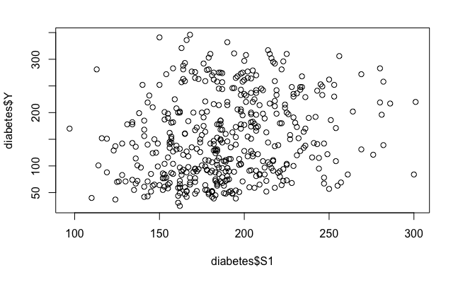

```r
plot(diabetes$S1, diabetes$Y)
```

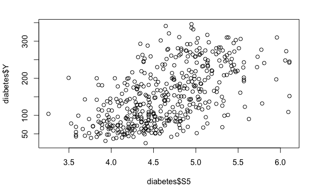

```r
plot(diabetes$S5, diabetes$Y)
```

### Cross validate the model on a test set

```r
yhat = predict(hlm, newdata=test)
R2 <- 1 - (sum((test$Y-yhat)^2)/sum((test$Y-mean(yhat))^2))
R2
```

```
[1] 0.4846154
```

### Training regression model using Caret

In Caret package, we can use `trainControl` function to automate a lot of training process. `trainControl` function can be used in conjunction with many training algorithms.

In `trainControl` function, you can specify how you are going to perform cross validation (how many folds, repeats). You can specify what methods to use for parameter search or parameter selection or performance analysis. Check out the reference link below for complete set of options.

Here we use trainControl to simply performance 3-fold cross validation on our diabetes data.

`trainControl` function is used in conjunction with `train` function. `train` function can receives a formula and a dataframe, or simply x and y variable. Then you can specify method (in this case, a linear model) and `trainControl` output.

```r
control <- trainControl(method="cv", number=3)
model <- train(Y~., data=diabetes_trans, method="lm", trControl=control)
model
```

```
Linear Regression

442 samples
 10 predictor

No pre-processing
Resampling: Cross-Validated (3 fold)
Summary of sample sizes: 295, 293, 296
Resampling results:

  RMSE       Rsquared
  0.7225052  0.485742

Tuning parameter 'intercept' was held constant at a value of TRUE
```

Reference: https://www.rdocumentation.org/packages/caret/versions/6.0-76/topics/trainControl https://www.rdocumentation.org/packages/caret/versions/6.0-76/topics/train